# DATA 467 Project Data Analysis and Linear Model Selection

#Data Analysis and Visualization

```r
# Loading the dataframes.
basketball_data <- read.csv('train.csv')

cols_list <- c('RANK', 'TEAM_ID', 'GP', 'MIN', 'FGM', 'FG_PCT', 'FG3M', 'FG3A', 'FG3_PCT', 'FTM', 'FTA', 'FT_PCT', 'OREB', 'DREB', 'REB', 'AST', 'STL', 'BLK', 'TOV', 'PF', 'PTS', 'EFF', 'AST_TOV', 'STL_TOV', 'CHANGED_FRANCHISE', 'SEASON_ID')

basketball_data <- basketball_data[, cols_list]
```

```r
summary(basketball_data)
```

```
##       RANK        TEAM_ID                GP             MIN
##  Min.   :  1   Min.   :1.611e+09   Min.   : 1.00   Min.   :   1
##  1st Qu.:119   1st Qu.:1.611e+09   1st Qu.:31.00   1st Qu.: 372
##  Median :239   Median :1.611e+09   Median :57.00   Median :1102
##  Mean   :241   Mean   :1.611e+09   Mean   :51.12   Mean   :1198
##  3rd Qu.:358   3rd Qu.:1.611e+09   3rd Qu.:73.00   3rd Qu.:1905
##  Max.   :603   Max.   :1.611e+09   Max.   :85.00   Max.   :3485
##       FGM            FG_PCT            FG3M             FG3A
##  Min.   :  0.0   Min.   :0.0000   Min.   :  0.00   Min.   :   0.0
##  1st Qu.: 43.0   1st Qu.:0.3990   1st Qu.:  0.00   1st Qu.:   3.0
##  Median :143.0   Median :0.4390   Median : 13.00   Median :  43.0
##  Mean   :187.2   Mean   :0.4367   Mean   : 37.97   Mean   : 106.2
##  3rd Qu.:286.0   3rd Qu.:0.4830   3rd Qu.: 62.00   3rd Qu.: 176.0
##  Max.   :978.0   Max.   :1.0000   Max.   :402.00   Max.   :1028.0
##     FG3_PCT            FTM              FTA            FT_PCT
##  Min.   :0.0000   Min.   :  0.00   Min.   :  0.0   Min.   :0.0000
##  1st Qu.:0.0000   1st Qu.: 16.00   1st Qu.: 24.0   1st Qu.:0.6470
##  Median :0.3090   Median : 55.00   Median : 76.0   Median :0.7500
##  Mean   :0.2487   Mean   : 90.29   Mean   :119.2   Mean   :0.6999
##  3rd Qu.:0.3680   3rd Qu.:127.00   3rd Qu.:170.0   3rd Qu.:0.8180
##  Max.   :1.0000   Max.   :756.00   Max.   :972.0   Max.   :1.0000
##       OREB             DREB            REB            AST             STL
##  Min.   :  0.00   Min.   :  0.0   Min.   :   0   Min.   :  0.0   Min.   :  0
##  1st Qu.: 12.00   1st Qu.: 42.0   1st Qu.:  57   1st Qu.: 19.0   1st Qu.: 10
##  Median : 35.00   Median :123.0   Median : 163   Median : 66.0   Median : 30
##  Mean   : 55.66   Mean   :155.4   Mean   : 211   Mean   :111.3   Mean   : 38
##  3rd Qu.: 77.00   3rd Qu.:226.0   3rd Qu.: 305   3rd Qu.:152.0   3rd Qu.: 57
##  Max.   :443.00   Max.   :894.0   Max.   :1247   Max.   :935.0   Max.   :231
##       BLK              TOV               PF             PTS
##  Min.   :  0.00   Min.   :  0.00   Min.   :  0.0   Min.   :   0.0
##  1st Qu.:  4.00   1st Qu.: 18.00   1st Qu.: 39.0   1st Qu.: 113.0
##  Median : 13.00   Median : 53.00   Median :100.0   Median : 376.0
##  Mean   : 24.35   Mean   : 69.01   Mean   :104.3   Mean   : 502.6
##  3rd Qu.: 31.00   3rd Qu.:103.00   3rd Qu.:159.0   3rd Qu.: 768.0
##  Max.   :332.00   Max.   :464.00   Max.   :371.0   Max.   :2832.0
##       EFF            AST_TOV          STL_TOV       CHANGED_FRANCHISE
##  Min.   :  -8.0   Min.   : 0.000   Min.   :0.0000   Length:13829
##  1st Qu.: 135.0   1st Qu.: 0.820   1st Qu.:0.3700   Class :character
##  Median : 453.0   Median : 1.330   Median :0.5300   Mode  :character
##  Mean   : 565.5   Mean   : 1.476   Mean   :0.6088
##  3rd Qu.: 869.0   3rd Qu.: 2.000   3rd Qu.:0.7500
##  Max.   :3039.0   Max.   :21.000   Max.   :7.0000
##   SEASON_ID
##  Length:13829
##  Class :character
##  Mode  :character
##
##
##
```

```r
table(basketball_data$CHANGED_FRANCHISE)
```

```
##
## False  True
##  9539  4290
```

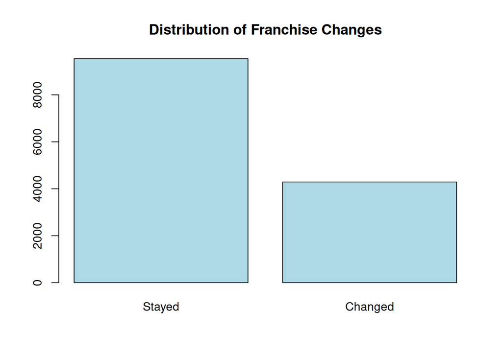

```r
barplot(table(basketball_data$CHANGED_FRANCHISE),
        names.arg = c("Stayed", "Changed"), col = "lightblue",
        main = "Distribution of Franchise Changes")
```

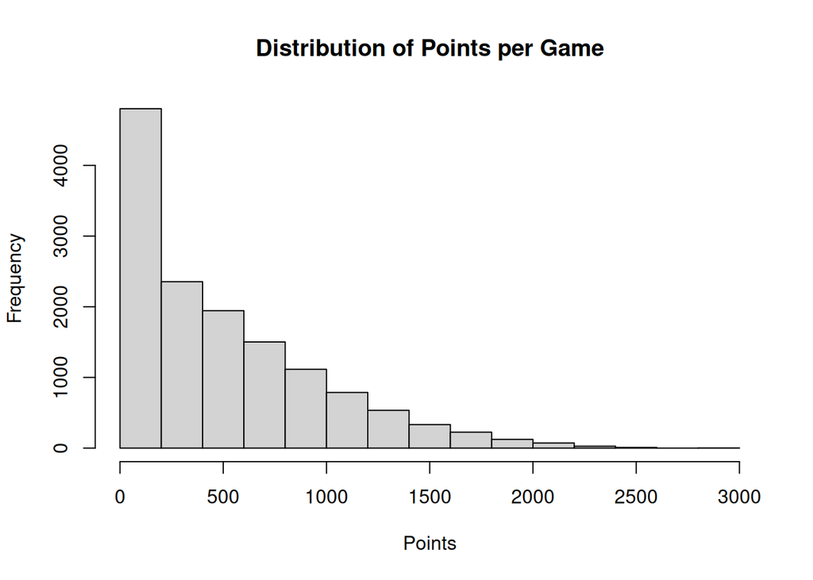

```r
hist(basketball_data$PTS, main = "Distribution of Points per Game", xlab = "Points")
```

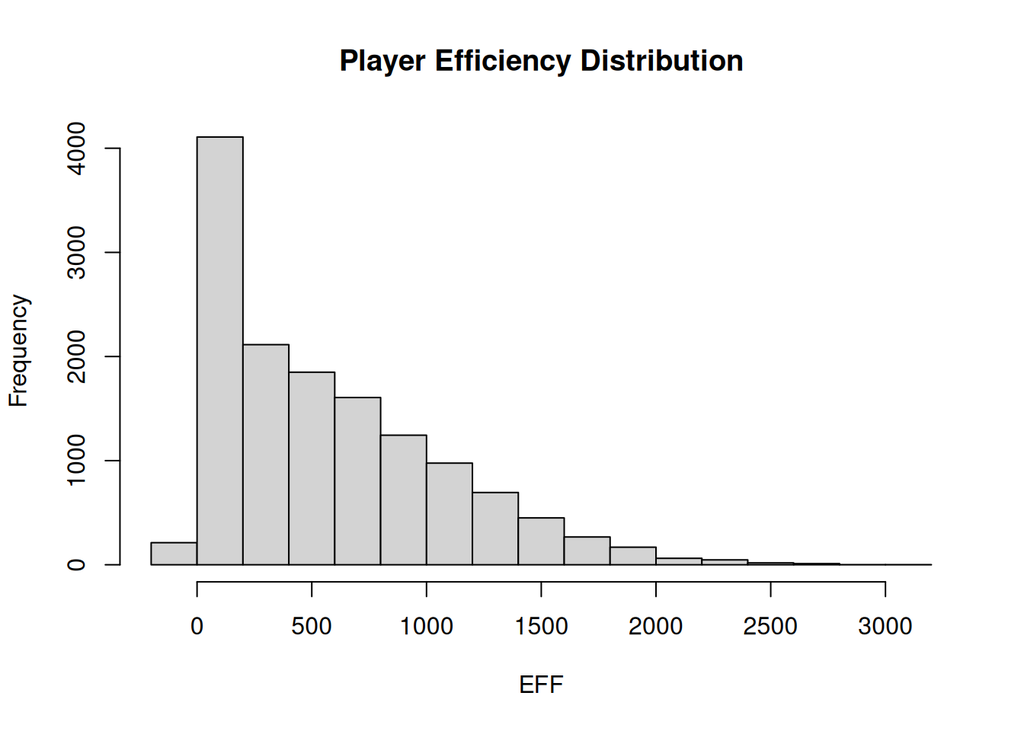

```r
hist(basketball_data$EFF, main = "Player Efficiency Distribution", xlab = "EFF")
```

#Logistic Regression Model We decided to use a logistic regression because our response variable is binomial, a player changes franchise or does not change franchise.

```r
library('tidyverse')
# Loading the dataframes.
train_df <- read.csv('train.csv')

#head(train_df, 10)

train_copy <- train_df

# Selecting desired columns.
cols_list <- c('RANK', 'TEAM_ID', 'GP', 'MIN', 'FGM', 'FG_PCT', 'FG3M', 'FG3A', 'FG3_PCT', 'FTM', 'FTA', 'FT_PCT', 'OREB', 'DREB', 'REB', 'AST', 'STL', 'BLK', 'TOV', 'PF', 'PTS', 'EFF', 'AST_TOV', 'STL_TOV', 'CHANGED_FRANCHISE', 'SEASON_ID')
train_df <- train_df[, cols_list]
#head(train_df, 10)

# Convert to factor.
train_df$CHANGED_FRANCHISE <- as.factor(train_df$CHANGED_FRANCHISE)
train_df$SEASON_ID <- as.factor(train_df$SEASON_ID)

# Check for missing values.
#sum(is.na(train_df))

#Logistic regression model
logit_mod <- glm(CHANGED_FRANCHISE ~ ., family=binomial(link='logit'), data = train_df)
```

```r
summary(logit_mod)
```

```
##
## Call:
## glm(formula = CHANGED_FRANCHISE ~ ., family = binomial(link = "logit"),
##     data = train_df)
##
## Coefficients: (2 not defined because of singularities)
##                    Estimate Std. Error z value Pr(>|z|)
## (Intercept)       9.040e+06  3.534e+06   2.558 0.010521 *
## RANK             -4.685e-03  7.051e-04  -6.645 3.04e-11 ***
## TEAM_ID          -5.612e-03  2.194e-03  -2.558 0.010521 *
## GP                6.780e-04  1.996e-03   0.340 0.734053
## MIN               3.643e-05  1.229e-04   0.296 0.767000
## FGM              -1.261e-03  9.497e-04  -1.328 0.184273
## FG_PCT           -1.762e-01  2.360e-01  -0.747 0.455131
## FG3M              8.186e-03  4.025e-03   2.034 0.041980 *
## FG3A             -3.087e-03  1.504e-03  -2.053 0.040073 *
## FG3_PCT           2.397e-02  1.349e-01   0.178 0.858962
## FTM               8.610e-04  2.246e-03   0.383 0.701448
## FTA              -8.039e-04  1.661e-03  -0.484 0.628459
## FT_PCT            1.225e-01  1.160e-01   1.055 0.291288
## OREB             -8.225e-04  1.222e-03  -0.673 0.500836
## DREB              3.064e-03  8.854e-04   3.460 0.000539 ***
## REB                      NA         NA      NA       NA
## AST               9.928e-05  9.098e-04   0.109 0.913103
## STL              -1.036e-03  1.694e-03  -0.612 0.540649
## BLK              -4.722e-03  1.400e-03  -3.372 0.000745 ***
## TOV               2.853e-03  1.707e-03   1.671 0.094683 .
## PF               -7.020e-04  8.128e-04  -0.864 0.387774
## PTS                      NA         NA      NA       NA
## EFF              -2.424e-03  7.161e-04  -3.384 0.000713 ***
## AST_TOV           5.576e-02  2.823e-02   1.975 0.048223 *
## STL_TOV          -6.334e-03  5.777e-02  -0.110 0.912684
## SEASON_ID1996-97  1.593e+01  1.122e+02   0.142 0.887104
## SEASON_ID1997-98  1.575e+01  1.122e+02   0.140 0.888314
## SEASON_ID1998-99  1.523e+01  1.122e+02   0.136 0.892002
## SEASON_ID1999-00  1.559e+01  1.122e+02   0.139 0.889497
## SEASON_ID2000-01  1.570e+01  1.122e+02   0.140 0.888664
## SEASON_ID2001-02  1.565e+01  1.122e+02   0.140 0.889008
## SEASON_ID2002-03  1.553e+01  1.122e+02   0.138 0.889853
## SEASON_ID2003-04  1.600e+01  1.122e+02   0.143 0.886544
```

[output cut: 15 more lines]

```
## SEASON_ID2019-20  1.592e+01  1.122e+02   0.142 0.887129
## SEASON_ID2020-21  1.591e+01  1.122e+02   0.142 0.887213
## SEASON_ID2021-22  1.600e+01  1.122e+02   0.143 0.886567
## SEASON_ID2022-23  1.591e+01  1.122e+02   0.142 0.887192
## SEASON_ID2023-24  1.597e+01  1.122e+02   0.142 0.886758
## ---
## Signif. codes:  0 '***' 0.001 '**' 0.01 '*' 0.05 '.' 0.1 ' ' 1
##
## (Dispersion parameter for binomial family taken to be 1)
##
##     Null deviance: 17128  on 13828  degrees of freedom
## Residual deviance: 16225  on 13778  degrees of freedom
## AIC: 16327
##
## Number of Fisher Scoring iterations: 15
```

##Diagnostics For Logistic Regression

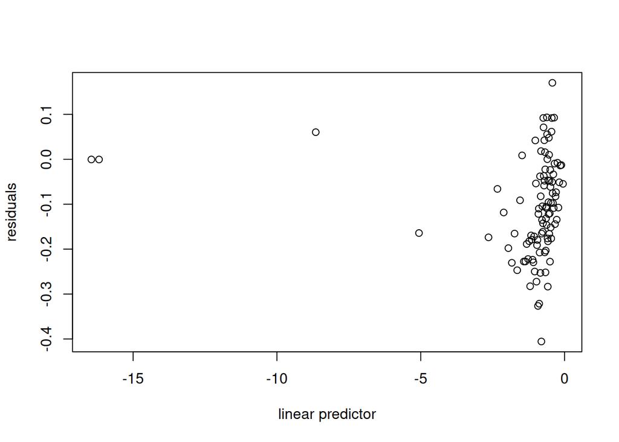

```r
#Residuals
train_df <- mutate(train_df,
                   residuals = residuals(logit_mod),
                   linpred = predict(logit_mod))

gdf <- group_by(train_df,
                bin = cut(linpred, breaks = unique(quantile(linpred, (1:100)/101))))

diagdf <- summarise(gdf,
                    residuals = mean(residuals),
                    linpred = mean(linpred))

plot(residuals ~ linpred, diagdf, xlab = "linear predictor")
```

Because there is not a random scatter in our fitted versus residual plot, we can say that this model does not meet our assumption of linearity.

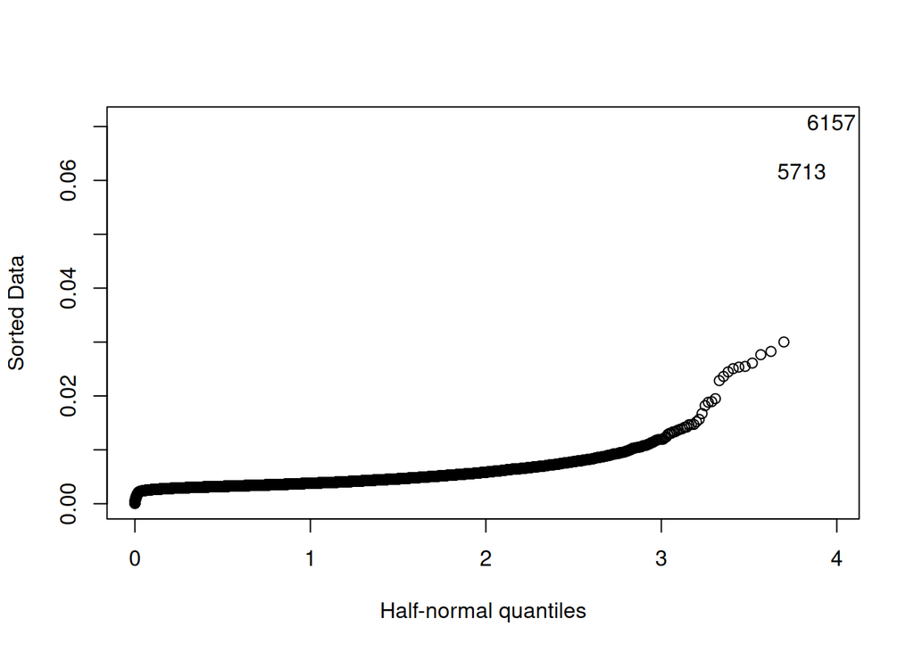

```r
#Half norm plot
library(faraway)
halfnorm(hatvalues(logit_mod))
```

From the half norm plot, we can see that there are only two outliers.

##Model Comparison

```r
#Smaller model from ommitting non significant predictors
columns <- c('RANK', 'TEAM_ID', 'FG3M', 'FG3A', 'DREB', 'BLK', 'EFF', 'AST_TOV', 'CHANGED_FRANCHISE')
new_train <- train_df[, columns]

new_train$CHANGED_FRANCHISE <- as.factor(new_train$CHANGED_FRANCHISE)

logit_mod_reduced <- glm(CHANGED_FRANCHISE ~ ., family=binomial(link='logit'), data = new_train)
#Summary of new log mod
summary(logit_mod_reduced)
```

```
##
## Call:
## glm(formula = CHANGED_FRANCHISE ~ ., family = binomial(link = "logit"),
##     data = new_train)
##
## Coefficients:
##               Estimate Std. Error z value Pr(>|z|)
## (Intercept)  8.938e+06  3.484e+06   2.566   0.0103 *
## RANK        -2.638e-03  3.886e-04  -6.788 1.14e-11 ***
## TEAM_ID     -5.550e-03  2.163e-03  -2.566   0.0103 *
## FG3M         4.091e-03  2.997e-03   1.365   0.1722
## FG3A        -9.430e-04  1.150e-03  -0.820   0.4121
## DREB         3.328e-03  4.265e-04   7.802 6.08e-15 ***
## BLK         -4.883e-03  1.046e-03  -4.668 3.05e-06 ***
## EFF         -2.203e-03  1.629e-04 -13.524  < 2e-16 ***
## AST_TOV      1.033e-01  2.029e-02   5.093 3.52e-07 ***
## ---
## Signif. codes:  0 '***' 0.001 '**' 0.01 '*' 0.05 '.' 0.1 ' ' 1
##
## (Dispersion parameter for binomial family taken to be 1)
##
##     Null deviance: 17128  on 13828  degrees of freedom
## Residual deviance: 16681  on 13820  degrees of freedom
## AIC: 16699
##
## Number of Fisher Scoring iterations: 4
```

```r
#Compare the reduced vs full models
anova(logit_mod_reduced, logit_mod, test = "Chisq")
```

|  | Resid. Df | Resid. Dev | Df | Deviance | Pr(>Chi) |
| --- | --- | --- | --- | --- | --- |
| 1 | 13820 | 16681.18 | NA | NA | NA |
| 2 | 13778 | 16224.75 | 42 | 456.4291 | 5.105753e-71 |

##Hypothesis Test Null Hypothesis($H_0$): The reduced model(Model 1) fits just as well as the full model(Model 2) and the additional predictors in the full model do not improve the model. Alternative Hypothesis($H_1$): The fulle model(Model 2) is better fit than the reduced model(Model 1). alpha = 0.05

Conclusion: Since the p-value is extremely small, we reject the null hypothesis. This indicates that the full model offers a significantly improved fit over the reduced model, and the additional predictors included in the full model are meaningful in explaining the response variable.